# 7-Exposure

# 1 General Instructions

This script does the following (manufacture sectors only):

1. Calculates employment levels by state-sector for year 2000 ($L_{i,s,2000}$) using Census data without person weights (to calculate shares later).
2. Calculates employment shares by state-sector for year 2000 using BLS data (then it joins these shares with ADH shares): $\frac{L_{i,s,2000}}{\sum_sL_{i,s,2000}}$.
3. Calculates the 2000-2007 change in imports from China to the US, $\Delta X_{C,US,s}^{2007-2000}$, and other advanced economies (Australia, Germany, Denmark, Spain, Finland, and Japan), $\Delta X_{C,OC,s}^{2007-2000}$, from WIOD data.
4. Runs a linear regression (with and without constant) using the change of sector US imports from China as the dependent variable and the change of sector advanced economies’ imports from China as the independent variable.
5. Computes the exposure measure using: i.- the 2000 state-sector employment shares derived from step 1) and step 2), ii.- predicted values of the regression in step 4) ($\widehat{\Delta X_{C,US,s}^{2007-2000}}$), and iii.- total US 2000 sales by sector ($R_{US,s,2000}$).

## 1.1 Input files

1. `0-Raw_Data/regions.csv`
2. `0-Raw_Data/sectors.csv`
3. `0-Raw_Data/CENSUS_2000/employment_2000.xls`
4. `0-Raw_Data/CENSUS_2000/PUMS5/PUMS5_`
5. `0-Raw_Data/emp_SAEMP25S_BLS.csv`
6. `1-Intermediate_Processed_Data/WIOD_countries.csv`
7. `1-Intermediate_Processed_Data/state_emp_2000.dta`

## 1.2 Output files

1. `1-Intermediate_Processed_Data/state_emp_share_2000.dta`
2. `2-Final_Data/exposures.xlsx`

#Calculate state-sector employment using Census data

Calculate $L_{i,s,2000}$ and $\sum_sL_{i,s,2000}$ using Census data without person weights.

```r
#List (and number) of states
regions <- read.csv("0-Raw_Data/regions.csv")
s_names <- regions %>% filter(status == "state")
s_names <- s_names$region
n_s <- length(s_names)

#Sector reclassification table (NAICS to final)
sectors_naics_final <- read.csv(paste("0-Raw_Data/sectors.csv", sep=""), header = TRUE, sep = ",", dec = ".")
sectors_naics_final <- sectors_naics_final %>%
  select(final_sector, naics) %>%
  mutate(naics = as.character(naics)) %>%
  distinct(final_sector, naics)

#Employment statistics for year 2000, by state
employment_pop <- read_excel("0-Raw_Data/CENSUS_2000/employment_2000.xls", skip = 12)
employment_pop <- employment_pop %>%
  dplyr::rename(state = ...1, Not_LF = ...8, employed = Employed, unemployed = Unemployed) %>%
  filter(is.na(state) == FALSE) %>%
  mutate(state = gsub(" ", "", state)) %>% #taking out spaces
  filter(state %in% s_names) %>% #only states
  mutate(unemployed = unemployed + Not_LF) %>% #out of sectors 1 to 13
  select(state, employed, unemployed) %>%
  mutate(unemployed = unemployed/1000, employed = employed/1000) #units in thousands (as WIOD)

#Loading Census PUMS
list <- c("01", "02", "04", "05", "06", "08", "09", setdiff(10:56, c(11,14,43,52)))
c <- 1
census_list <- vector("list", length = n_s)
for (i in list){
CENSUS_PUMS <- read_csv(paste("0-Raw_Data/CENSUS_2000/PUMS5/PUMS5_", i,".txt", sep=""), col_names = FALSE, col_types = cols())
CENSUS_PUMS$state <- s_names[c]

# Creating variables: age, employment status, and industry info for each US state
CENSUS_PUMS <- CENSUS_PUMS %>%
  mutate(len = nchar(X1)) %>% #only two len: Households and Persons; len matches with dictionary
  mutate(type = substr(X1, start=1, stop=1)) %>%
  filter(type=="P") %>% #keeping only persons and NOT households
  mutate(age = as.numeric(substr(X1, start=25, stop=26))) %>%
  filter(age >=25 & age <=65) %>%
  mutate(employ_status = as.numeric(substr(X1, start=154, stop=154))) %>%
  filter(is.na(employ_status) == FALSE & ((employ_status>=1 & employ_status<=3)|employ_status==6)) %>%
  mutate(employ_status = as.numeric(recode( as.character(employ_status), '6' ="0", '3' ="0", '2' = "1", '1' = "1"))) %>%
  mutate(naics = substr(X1, start=215, stop=217)) %>% #industry information
  mutate(naics = ifelse(employ_status == 0, NA, naics)) %>%
  filter((employ_status == 0 & is.na(naics) == TRUE)|(employ_status == 1 & is.na(naics) == FALSE)) %>%
  mutate(naics = ifelse(naics == "23 ", "230", naics)) %>%
  mutate(naics = ifelse(naics == "31M", "313", naics)) %>%
  mutate(naics = ifelse(naics == "4MS", "423", naics)) %>%
  left_join(sectors_naics_final, by=c('naics'='naics')) %>% #NAICS to final sector
  dplyr::rename(sector = final_sector) %>%
  filter(is.na(sector) == FALSE) %>% #NAICS that are not in final sectors
  select(-X1)
census_list[[c]] <- CENSUS_PUMS #each list in census_list contains all the micro-info for each US state
rm(CENSUS_PUMS)
print(s_names[c])
c <- c + 1
}
```

```
[1] "Alabama"
[1] "Alaska"
[1] "Arizona"
[1] "Arkansas"
[1] "California"
[1] "Colorado"
[1] "Connecticut"
[1] "Delaware"
[1] "Florida"
[1] "Georgia"
[1] "Hawaii"
[1] "Idaho"
[1] "Illinois"
[1] "Indiana"
[1] "Iowa"
```

[output cut: 35 more lines]

```r
census <- rbindlist(census_list)
rm(census_list)

#computing employment and non-employment, by sector and state
census <- census %>%
  group_by(state, sector) %>%
  mutate(num_employ = n()) %>%
  ungroup() %>%
  distinct(state, sector, .keep_all = TRUE) %>%
  select(state, sector, num_employ) %>%
  arrange(state, sector) %>%
  mutate(num_employ = ifelse(sector == 0, 0, num_employ)) %>% #non-employed total (not sample) will be added directly
  group_by(state) %>%
  mutate(tot = sum(num_employ)) %>%
  ungroup() %>%
  mutate(rel = num_employ/tot) %>%
  left_join(employment_pop, by=c('state'='state')) %>% #total employed people
  mutate(employ = rel*employed) %>%
  mutate(employ = ifelse(sector == 0, unemployed, employ)) %>%
  select(state, sector, employ)
L_2000 <- spread(census, sector, employ, fill = NA, convert = TRUE,  drop = TRUE, sep = NULL)

#Calculate employment by state. And drop (from state-sector employment) agriculture, services, and non-employed.
L <- melt(L_2000, id.vars=c("state"), variable.name="sector", value.name = "employ")
L <- L %>%
  mutate(sector = as.numeric(gsub("X", "", sector))) %>%
  filter(sector != 0) %>%
  group_by(state) %>%
  mutate(employ_state = sum(employ)) %>%
  ungroup() %>%
  filter(sector <= 12)
```

# 2 Calculate state-sector employment shares using BLS data

Calculate $\frac{L_{i,s,2000}}{\sum_sL_{i,s,2000}}$ using BLS data.

```r
#BLS employment
bls <- read.csv("0-Raw_Data/emp_SAEMP25S_BLS.csv", header = TRUE)

#Drop footnotes, change variables to the correct format, and keep relevant lines
bls <- bls[1:6180,]
bls <- bls %>%
  mutate(GeoFips = as.character(GeoFips)) %>%
  mutate(Jobs = as.numeric(Jobs)) %>%
  filter(!is.na(Jobs)) %>%
  filter(LineCode > 60 & LineCode != 80)

#Number of indents in Description (to identify subcategories)
bls$indent <- NA
temp_space <- "  "
spaces <- c("  ","  ","  ","  ","  ")
for (i in 2:5) {
  bef <- i - 1
  spaces[i] <- paste0(spaces[bef], temp_space)
}
for (i in 5:1) {
  bls$indent[grepl(spaces[i], bls$Description) & is.na(bls$indent)] <- i
}

#Keep sectors: farm employment or manuf (disaggregated) or services
bls <- bls %>%
  filter(indent == 3 | LineCode == 70 |
            (LineCode >= 400 & LineCode <= 480) |
            (LineCode >= 800 & LineCode <= 880) |
            (LineCode >= 500 & LineCode <= 540) |
            LineCode == 560 | LineCode ==570 | (LineCode >= 700 & LineCode <= 736) |
            (LineCode >= 621 & LineCode <= 628) |
            (LineCode >= 540 & LineCode <= 544))

#Dropping totals for manuf, durables, and non-durables
bls <- bls %>%
  filter(!(LineCode == 410 | LineCode == 450 |
             LineCode == 400 | LineCode == 800 |
             LineCode == 500 | LineCode == 700 |
             LineCode == 730 | LineCode == 620 |
             LineCode == 540))


#Check: sum of employment = total employment of USA
bls <- bls %>%
  group_by(GeoName) %>%
  mutate(tot_emp = sum(Jobs)) %>%
  arrange(GeoFips,LineCode)
if (mean(bls$tot_emp[bls$GeoName == "United States"], na.rm = TRUE) == 165370800) {
  print("check if sum of employment = total employment of USA: TRUE")
} else {
  print("check if sum of employment = total employment of USA: FALSE")
    stop()
}
```

```
[1] "check if sum of employment = total employment of USA: TRUE"
```

```r
#Remove column for the number of indents, and remove indents from Description.
bls <- bls %>% select(-indent)
bls$Description <- str_trim(bls$Description)

## ASSIGNING WIOD SECTORS

bls$wiod_sector <- NA

# Agriculture, Hunting, Forestry and Fishing
bls$wiod_sector[bls$LineCode %in% c(100)] <- 1
# Mining and Quarrying
bls$wiod_sector[bls$LineCode %in% c(200)] <- 2
# Food, Beverages and Tobacco
bls$wiod_sector[bls$LineCode %in% c(453, 456)] <- 3
# Textiles and Textile Products
bls$wiod_sector[bls$LineCode %in% c(459, 462)] <- 4
# Leather, Leather and Footwear
bls$wiod_sector[bls$LineCode %in% c(480)] <- 5
# Wood and Products of Wood and Cork
bls$wiod_sector[bls$LineCode %in% c(413)] <- 6
# Pulp, Paper, Paper, Printing and Publishing
bls$wiod_sector[bls$LineCode %in% c(465, 468)] <- 7
# Coke, Refined Petroleum and Nuclear Fuel
bls$wiod_sector[bls$LineCode %in% c(474)] <- 8
# Chemicals and Chemical Products
bls$wiod_sector[bls$LineCode %in% c(471)] <- 9
# Rubber and Plastics
bls$wiod_sector[bls$LineCode %in% c(477)] <- 10
# Other Non-Metallic Mineral
bls$wiod_sector[bls$LineCode %in% c(420)] <- 11
# Basic Metals and Fabricated Metal
bls$wiod_sector[bls$LineCode %in% c(423, 426)] <- 12
# Machinery, Nec
bls$wiod_sector[bls$LineCode %in% c(429)] <- 13
# Electrical and Optical Equipment
bls$wiod_sector[bls$LineCode %in% c(432)] <- 14
# Transport Equipment
bls$wiod_sector[bls$LineCode %in% c(435, 438)] <- 15
# Manufacturing, Nec; Recycling
bls$wiod_sector[bls$LineCode %in% c(417, 441, 444)] <- 16
# Electricity, Gas and Water Supply
bls$wiod_sector[bls$LineCode %in% c(570)] <- 17
# Construction
bls$wiod_sector[bls$LineCode %in% c(300)] <- 18
# Sale, Maintenance and Repair of Motor Vehicles and Motorcycles; Retail Sale of Fuel
bls$wiod_sector[bls$LineCode %in% c(624)] <- 19
# Wholesale Trade and Commission Trade, Except of Motor Vehicles and Motorcycles
bls$wiod_sector[bls$LineCode %in% c(610)] <- 20
# Retail Trade, Except of Motor Vehicles and Motorcycles; Repair of Household Goods
bls$wiod_sector[bls$LineCode %in% c(621, 622, 623, 625, 626, 627, 628)] <- 21
# Hotels and Restaurants
bls$wiod_sector[bls$LineCode %in% c(805)] <- 22
# Inland Transport
bls$wiod_sector[bls$LineCode %in% c(510, 520)] <- 23
# Water Transport
bls$wiod_sector[bls$LineCode %in% c(530)] <- 24
#Air Transport
bls$wiod_sector[bls$LineCode %in% 542] <- 25
#Other Supporting and Auxiliary Transport Activities; Activities of Travel Agencies
bls$wiod_sector[bls$LineCode %in% c(541, 543, 544)] <- 26
#Post and Telecommunications
bls$wiod_sector[bls$LineCode %in% 560] <- 27
#Financial Intermediation
bls$wiod_sector[bls$LineCode %in% c(710, 731, 732, 733, 735, 736)] <- 28
#Real Estate Activities
bls$wiod_sector[bls$LineCode %in% 734] <- 29
#Renting of M&Eq and Other Business Activities
bls$wiod_sector[bls$LineCode %in% c(820, 825, 830, 875, 880)] <- 30
#Public Admin and Defence; Compulsory Social Security
bls$wiod_sector[bls$LineCode %in% c(910, 920, 930)] <- 31
#Education
bls$wiod_sector[bls$LineCode %in% 855] <- 32
#Health and Social Work
bls$wiod_sector[bls$LineCode %in% c(845, 860)] <- 33
#Other Community, Social and Personal Services
bls$wiod_sector[bls$LineCode %in% c(810, 835, 840, 865, 870)] <- 34
#Private Households with Employed Persons
bls$wiod_sector[bls$LineCode %in% c(815, 850)] <- 35

## ASSIGNING FINAL SECTORS

bls$ruv_sector <- NA

# 1. (NAICS 311-312) Food Products, Beverage, and Tobacco Products (c3)
bls$ruv_sector[bls$wiod_sector == 3] <- 1
# 2. (NAICS 313-316) Textile, Textile Product Mills, Apparel, Leather, and Allied Products (c4-c5)
bls$ruv_sector[bls$wiod_sector == 4 | bls$wiod_sector == 5] <- 2
# 3. (NAICS 321-323) Wood Products, Paper, Printing, and Related Support Activities (c6-c7)
bls$ruv_sector[bls$wiod_sector == 6 | bls$wiod_sector == 7] <- 3
# 4. (NAICS 211-213, 324) Petroleum and Coal Products (c8)
# Mining, Quarrying, and Oil and Gas Extraction (c2)
bls$ruv_sector[bls$wiod_sector == 8 | bls$wiod_sector == 2] <- 4
# 5. (NAICS 325) Chemical (c9)
bls$ruv_sector[bls$wiod_sector == 9] <- 5
# 6. (NAICS 326) Plastics and Rubber Products (c10)
bls$ruv_sector[bls$wiod_sector == 10] <- 6
# 7. (NAICS 327) Nonmetallic Mineral Products (c11)
bls$ruv_sector[bls$wiod_sector == 11] <- 7
# 8. (NAICS 331-332) Primary Metal and Fabricated Metal Products (c12)
bls$ruv_sector[bls$wiod_sector == 12] <- 8
# 9. (NAICS 333) Machinery (c13)
bls$ruv_sector[bls$wiod_sector == 13] <- 9
# 10. (NAICS 334-335) Computer and Electronic Products, and Electrical Equipment and Appliances (c14)
bls$ruv_sector[bls$wiod_sector == 14] <- 10
# 11. (NAICS 336) Transportation Equipment (c15)
bls$ruv_sector[bls$wiod_sector == 15] <- 11
# 12. (NAICS 337-339) Furniture and Related Products, and Miscellaneous Manufacturing (c16)
bls$ruv_sector[bls$wiod_sector == 16] <- 12
# 13. (NAICS 23) Construction (c18)
bls$ruv_sector[bls$wiod_sector == 18] <- 13
# 14. (NAICS 42-45) Wholesale and Retail Trade (c19-c21)
bls$ruv_sector[bls$wiod_sector == 19 | bls$wiod_sector == 20 | bls$wiod_sector == 21] <- 14
# 15. (NAICS 481-488) Transport Services (c23-c26)
bls$ruv_sector[bls$wiod_sector == 23 | bls$wiod_sector == 24 | bls$wiod_sector == 25 | bls$wiod_sector == 26] <- 15
# 16. (NAICS 511-518) Information Services (c27)
bls$ruv_sector[bls$wiod_sector == 27] <- 16
# 17. (NAICS 521-525) Finance and Insurance (c28)
bls$ruv_sector[bls$wiod_sector == 28] <- 17
#18.    (NAICS 531-533)  Real Estate (c29-c30);
bls$ruv_sector[bls$wiod_sector == 29 | bls$wiod_sector == 30] <- 18
#19.    (NAICS 61) Education (c32);
bls$ruv_sector[bls$wiod_sector == 32] <- 19
#20.    (NAICS 621-624) Health Care (c33);
bls$ruv_sector[bls$wiod_sector == 33] <- 20
#21.    (NAICS 721-722) Accommodation and Food Services (c22);
bls$ruv_sector[bls$wiod_sector == 22] <- 21
#22.    (NAICS 493, 541, 55, 561, 562, 711-713, 811-814) Other Services (c34).
bls$ruv_sector[bls$wiod_sector == 34] <- 22
#23.    (NAICS 111-115) Agriculture, Forestry, Fishing, and Hunting (c1)
bls$ruv_sector[bls$wiod_sector == 1] <- 23
#final
bls$ruv_sector[bls$ruv_sector >=13 & bls$ruv_sector < 23 & !is.na(bls$ruv_sector)] <- 13
bls$ruv_sector[bls$ruv_sector == 23] <- 14

#Computing BLS employment shares, and joining ADH employment shares.

#Rename variables
bls <- bls %>% rename(region = GeoName)
# Convert region to lower case
bls$region <- tolower(bls$region)
# Remove spaces in region variable
bls$region <- str_replace(bls$region," ","")

#Load ADH data (to obtain "1-Intermediate_Processed_Data/state_emp_2000.dta", one must run first ADH-0-cbp2000_imputations.do, ADH-1-cbp2000_to_cz.do, and ADH-2-cz_to_states.do, in that order; these scripts are at RUV/1-Data-Codes/0-Raw_Data/ADH_employment).

ADH <- read_dta("1-Intermediate_Processed_Data/state_emp_2000.dta")

#Use ADH data to only keep states.
regions <- ADH %>%
  group_by(region) %>%
  summarize(key = 1)
bls <- left_join(bls, regions, by = "region")
bls <- bls %>% filter(key == 1 | region == "alaska") %>% select(-key)

#Computing employment shares.
bls <- bls %>% group_by(region) %>%
  mutate(emp_state = sum(Jobs)) %>%
  group_by(region, ruv_sector) %>%
  mutate(emp_state_sector = sum(Jobs))%>%
  summarise(emp_state = mean(emp_state), emp_state_sector = mean(emp_state_sector))
tot_US <- sum(bls$emp_state_sector, na.rm = TRUE)
bls <- bls %>% filter(!is.na(ruv_sector))
bls$share_sector_state <- bls$emp_state_sector / bls$emp_state

# Keep manufacturing
bls <- bls %>% filter(ruv_sector <= 12)

#Keep relevant variables
bls <- bls %>%
  select(region, ruv_sector, share_sector_state)%>%
  rename(sector = ruv_sector, share_bls = share_sector_state)
bls$share_bls[is.na(bls$share_bls)] <- 0

# Balance Panel
bls <- bls %>%
  ungroup() %>%
  complete(region, sector, fill = list(share_bls = 0))

# Join with ADH shares.
state_emp_share_2000 <- merge(bls, ADH, by = c("region", "sector"), all = TRUE)

# Save output
state_emp_share_2000 <- state_emp_share_2000 %>% mutate(share_bls = round(share_bls,digits = 8))
haven::write_dta(state_emp_share_2000, "1-Intermediate_Processed_Data/state_emp_share_2000.dta")
state_emp_share_2000 <- state_emp_share_2000 %>%
  dplyr::rename(state = region)
```

# 3 The change in imports from China

Calculate $\Delta X_{C,US,s}^{2007-2000}$ and $\Delta X_{C,OC,s}^{2007-2000}$

```r
#WIOD
WIOD <- read.csv("1-Intermediate_Processed_Data/WIOD_countries.csv")
#List the countries (China, USA, and other advanced)
list_countries <- c("USA", "CHN", "AUS", "DEU", "DNK", "ESP", "FIN", "JPN")
adv_countries <- c("AUS", "DEU", "DNK", "ESP", "FIN", "JPN")

#Select years and importers of interest.
WIOD_1 <- WIOD %>%
  filter(year == 2000 | year == 2007) %>%
  filter(importer_country %in% list_countries) %>%
  select(-importer)

#Drop all exporters but China, and select manufacture (sectors from 1 to 12). Then calculate imports from China for US and for OC.
WIOD_1 <- melt(WIOD_1, id.vars=c("year", "importer_country", "sector"), variable.name="exporter", value.name = "value")
WIOD_1 <- WIOD_1 %>%
  mutate(exporter = gsub("value_", "", exporter)) %>%
  filter(exporter == "CHN" & importer_country != "CHN" & sector <= 12) %>%
  mutate(importer_country = ifelse(importer_country %in% adv_countries, "adv", importer_country)) %>%
  group_by(year, importer_country, exporter, sector) %>%
  mutate(value = sum(value)) %>%
  ungroup() %>%
  distinct(year, importer_country, exporter, sector, .keep_all = TRUE) %>%
  mutate(value_2000 = ifelse(year == 2000, value, 0)) %>%
  mutate(value_2007 = ifelse(year == 2007, value, 0)) %>%
  group_by(importer_country, exporter, sector) %>%
  mutate(value_2000 = max(value_2000)) %>%
  mutate(value_2007 = max(value_2007)) %>%
  ungroup() %>%
  distinct(importer_country, exporter, sector, .keep_all = TRUE) %>%
  mutate(M_change = value_2007 - value_2000) %>%
  select(-year, -value, -value_2000, -value_2007)

#Calculate change in imports. And prepare data set for regression.
x_data <- WIOD_1 %>%
  filter(importer_country == "adv") %>%
  dplyr::rename(delta_M_others = M_change) %>%
  select(sector, delta_M_others)
data <- WIOD_1 %>%
  filter(importer_country == "USA") %>%
  dplyr::rename(delta_M_USA = M_change) %>%
  left_join(x_data, by=c("sector"="sector"))
```

## 3.1 Run regression between change in imports

Run the following regression:
$$\Delta
X_{C,US,s}^{2007-2000}= b_2\Delta
X_{C,OC,s}^{2007-2000}+\varepsilon_s$$
(and another with intercept), and extract the predicted values: $\widehat{\Delta X_{C,US,s}^{2007-2000}}$.

```r
#regressions
reg_cons <- lm(data$delta_M_USA ~ data$delta_M_others)
reg_nocons <- lm(data$delta_M_USA ~ data$delta_M_others -1)
summary(reg_nocons) #Note that the model without intercept has a 0.99 R^2.
```

```
Call:
lm(formula = data$delta_M_USA ~ data$delta_M_others - 1)

Residuals:
            Min              1Q          Median              3Q
-5180.594228555 -3391.419656309  -965.059076907   708.908788221
            Max
 4288.765179277

Coefficients:
                           Estimate      Std. Error  t value
data$delta_M_others 1.3621654744701 0.0373880183342 36.43321
                               Pr(>|t|)
data$delta_M_others 0.00000000000080238 ***
---
Signif. codes:  0 '***' 0.001 '**' 0.01 '*' 0.05 '.' 0.1 ' ' 1

Residual standard error: 3013.03549303 on 11 degrees of freedom
Multiple R-squared:  0.991781100493,    Adjusted R-squared:  0.991033927811
F-statistic: 1327.37869544 on 1 and 11 DF,  p-value: 0.000000000000802375482488
```

```r
#predicted values
data$hat_cons <- predict(reg_cons, data.frame(data$delta_M_others))
data$hat_nocons <- predict(reg_nocons, data.frame(data$delta_M_others))
data_reg <- data %>% select(sector, hat_cons, hat_nocons)
```

# 4 Exposure measure(s)

Calculate
$$Exposure_i \equiv
\sum_{s=1}^S\frac{L_{i,s,2000}}{L_{i,2000}}\frac{\widehat{\Delta
X_{C,US,s}^{2007-2000}}}{R_{US,s,2000}}$$
where $L_{i,2000}\equiv\sum_sL_{i,s,2000}$

```r
#Total US sales by sector in year 2000
R_US <- WIOD %>%
  filter(year == 2000 & sector <= 12) %>%
  select(importer_country, sector, value_USA)
R_US <- melt(R_US, id.vars=c("importer_country", "sector"), variable.name="exporter", value.name = "value")
R_US <- R_US %>%
  mutate(exporter = gsub("value_", "", exporter)) %>%
  group_by(exporter, sector) %>%
  mutate(sales = sum(value)) %>%
  ungroup() %>%
  distinct(exporter, sector, .keep_all = TRUE) %>%
  select(sector, sales)

#Calculate Exposure_i
final <- L %>%
  left_join(R_US, by=c("sector"="sector")) %>%
  left_join(data_reg, by=c("sector"="sector")) %>%
  mutate(state = tolower(state)) %>%
  left_join(state_emp_share_2000, by=c("state"="state", "sector"="sector")) %>%
  mutate(exposure_cons = ( (employ*hat_cons)/(employ_state*sales) ) ) %>%
  mutate(exposure_nocons = ( (employ*hat_nocons)/(employ_state*sales) ) ) %>%
  mutate(exposure_cons_bls = ( (share_bls*hat_cons)/(sales) ) ) %>%
  mutate(exposure_nocons_bls = ( (share_bls*hat_nocons)/(sales) ) ) %>%
  group_by(state) %>%
  mutate(ADH_EXP_pred = sum(exposure_cons)) %>%
  mutate(ADH_EXP_pred_nocons = sum(exposure_nocons)) %>%
  mutate(ADH_EXP_pred_bls = sum(exposure_cons_bls)) %>%
  mutate(ADH_EXP_pred_nocons_bls = sum(exposure_nocons_bls)) %>%
  ungroup() %>%
  distinct(state, .keep_all = TRUE) %>%
  dplyr::rename(region = state) %>%
  select(region, ADH_EXP_pred_nocons, ADH_EXP_pred, ADH_EXP_pred_nocons_bls, ADH_EXP_pred_bls)

#Correlation between Census and BLS exposures (with and without intercept)
corr_cons <- cor(final$ADH_EXP_pred, final$ADH_EXP_pred_bls)
print(corr_cons)
```

```
[1] 0.970367627250176
```

```r
corr_nocons <- cor(final$ADH_EXP_pred_nocons, final$ADH_EXP_pred_nocons_bls)
print(corr_nocons)
```

```
[1] 0.973087451736912
```

```r
#correlation between Census shares and BLS shares
temp_L <- L %>%
  arrange(state, sector) %>%
  mutate(share_L = employ/employ_state) %>%
  select(state, sector, share_L)
corr_employ_BLS <- cor(temp_L$share_L, state_emp_share_2000$share_bls)
print(corr_employ_BLS)
```

```
[1] 0.887989275067222
```

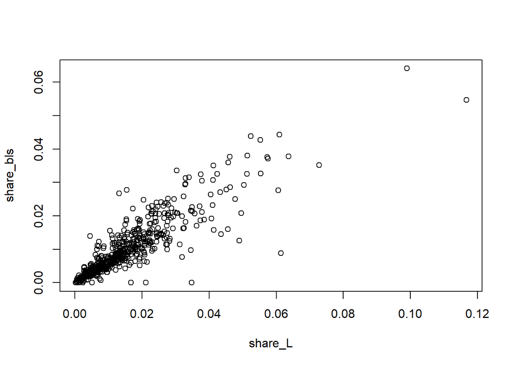

```r
plot(x = temp_L$share_L, y = state_emp_share_2000$share_bls, xlab = "share_L", ylab = "share_bls")
```

```r
write_xlsx(final, path = "2-Final_Data/exposures.xlsx")
```